# 07 Ensemble learning

#### Predictive Modeling and Analytics

Marko Robnik-Šikonja, November 2016

## Bagging

We use `randomForest` package and Boston housing data set from MASS package to predict numeric variable median housing value (medv). First we split the data for training and testing.

```r
library(randomForest)
library(MASS)
set.seed(1)
train <- sample(1:nrow(Boston),0.7*nrow(Boston))
test <- 1:nrow(Boston)[-train]
attach(Boston)
boston.test <- medv[test]
```

Note that bagging is a variant of random forest which uses all variables in random selection of features during construction of the trees.

```r
bag.boston=randomForest(medv~.,data=Boston,subset=train,mtry=ncol(Boston)-1,importance=TRUE)
bag.boston
```

```
Call:
 randomForest(formula = medv ~ ., data = Boston, mtry = ncol(Boston) -      1, importance = TRUE, subset = train)
               Type of random forest: regression
                     Number of trees: 500
No. of variables tried at each split: 13

          Mean of squared residuals: 10.45792
                    % Var explained: 87.58
```

Let us plot predictions against true values and estimate MSE on test set.

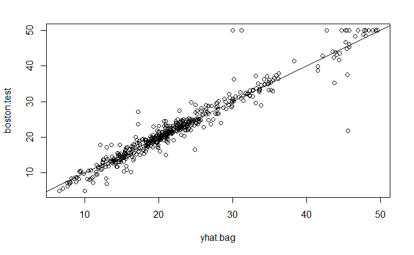

```r
yhat.bag = predict(bag.boston,newdata=Boston[test,])
plot(yhat.bag, boston.test)
abline(0,1)
```

```r
mean((yhat.bag-boston.test)^2)
```

```
[1] 5.927538
```

```r
bag.boston=randomForest(medv~.,data=Boston,subset=train,mtry=13,ntree=25)
yhat.bag = predict(bag.boston,newdata=Boston[test,])
mean((yhat.bag-boston.test)^2)
```

```
[1] 5.930454
```

## Random forests

For random forest we just decrease number of randomly chosen variables controlled by parameter `mtry`. Default value for classification is square root of the number of predictors, and for regression it is one third of the number of predictors.

```r
set.seed(1)
rf.boston=randomForest(medv~.,data=Boston,subset=train,mtry=6,importance=TRUE)
yhat.rf = predict(rf.boston,newdata=Boston[test,])
mean((yhat.rf-boston.test)^2)
```

```
[1] 4.845564
```

We can also use random forest to estimate importance of variables.

```r
importance(rf.boston)
```

```
          %IncMSE IncNodePurity
crim    12.982573    1257.46995
zn       2.422768      96.17846
indus   10.414672    1557.88678
chas     1.799324     115.30764
nox     15.199880    1696.90140
rm      36.878711   10157.47982
age     11.832344     833.73027
dis     15.700972    1741.85212
rad      4.573105     134.77732
tax     10.869029     559.08474
ptratio 12.312712    1103.25495
black    6.864422     510.74503
lstat   30.408993    9524.12000
```

Importance of variables can also be plotted with provided function.

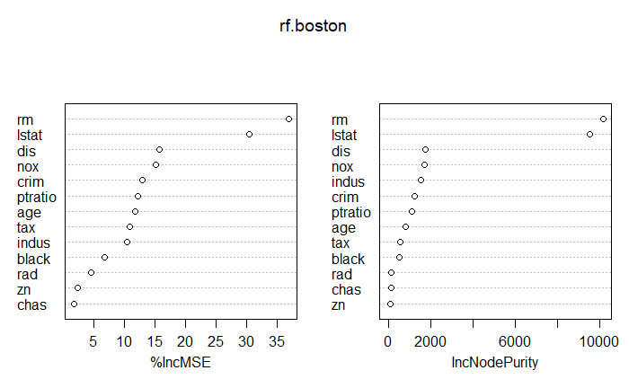

```r
varImpPlot(rf.boston)
```

## Boosting

Boosting is implemented in `gbm`package. For regression we use `distribution="gaussian"`. For classification problem we would set `distribution="bernoulli"`. The parameter `interaction.depth` limits the depth of trees.

```r
library(gbm)
set.seed(1)
boost.boston=gbm(medv~.,data=Boston[train,],distribution="gaussian",n.trees=5000,interaction.depth=4)
```

The summary function outputs impact of variables.

|  | var | rel.inf |
| --- | --- | --- |
| lstat | lstat | 36.0966983 |
| rm | rm | 28.9655928 |
| dis | dis | 9.8006825 |
| crim | crim | 6.1122273 |
| age | age | 4.2272023 |
| nox | nox | 3.9971368 |
| black | black | 3.3161877 |
| ptratio | ptratio | 2.6602045 |
| tax | tax | 1.7796548 |
| indus | indus | 1.6257906 |

[output cut: 3 more lines]

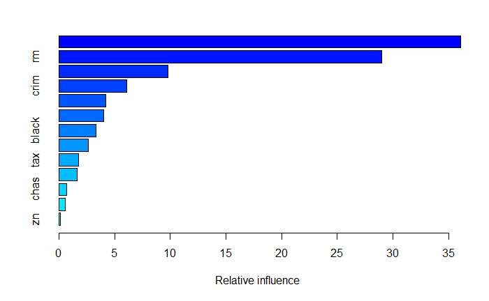

```r
summary(boost.boston)
```

We can also produce partial dependence plots for these two variables. These plots illustrate the marginal effect of the selected variables on the response after integrating out the other variables. In this case, as we might expect, median house prices are increasing with rm and decreasing with lstat.

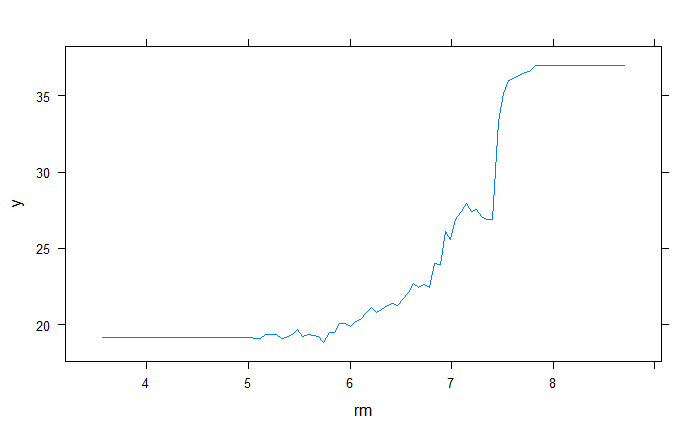

```r
par(mfrow=c(1,2))
plot(boost.boston,i="rm")
```

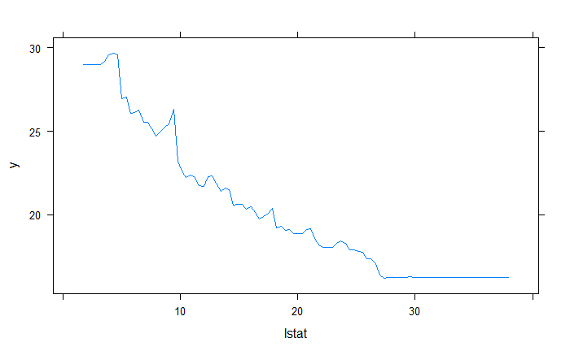

```r
plot(boost.boston,i="lstat")
```

Predict error on the test set.

```r
yhat.boost=predict(boost.boston,newdata=Boston[test,],n.trees=5000)
mean((yhat.boost-boston.test)^2)
```

```
[1] 3.519343
```

We can also modify regularization parameter `shrinkage`.

```r
boost.boston=gbm(medv~.,data=Boston[train,],distribution="gaussian",n.trees=5000,interaction.depth=4,shrinkage=0.2,verbose=F)
yhat.boost=predict(boost.boston,newdata=Boston[test,],n.trees=5000)
mean((yhat.boost-boston.test)^2)
```

```
[1] 3.751409
```

### Exercise

1. Use bagging, random forest and boosting to classify Sales variable on Carseats data set into two categories, High (Sales>8) and Low (Sales<=8).
2. Using the above data set, analyze the number of trees in bagging, parameter `mtry` in random forests, and `shrinkag`e and `interaction.depth` in boosting. Visualize the results.
3. Random forest for classification is also implemented in the CORElearn package. Try using it on the classification data set iris and visualize its outputs.
4. (optional) Implement stacking of classifiers, where you use the returned probability scores of baseline classifiers. As baseline classifiers use logistic regression, kNN algorithm, random forest and naive Bayes. Apply the approach to the provided spambase. Present reliable comparison of the stacking results and results of baseline classifiers.